# Aim: To build a Machine learning model that can predict if an existing customer is more likely to buy a new car using Random Forest

## 0.Import Packages

```python
! pip install -r https://raw.githubusercontent.com/aso-uts/labs_datasets/main/36106-mlaa/requirements.txt
```

```python
import pandas as pd
import numpy as np
from sklearn.model_selection import train_test_split
from sklearn.preprocessing import LabelEncoder
from sklearn.ensemble import RandomForestClassifier
from sklearn.metrics import accuracy_score, precision_score, recall_score, f1_score, roc_auc_score

import warnings
warnings.filterwarnings("ignore")
```

## 1. Load data

```python
data = pd.read_csv("C:\\Users\\shiva\\Downloads\\repurchase_dataset.csv")
```

## 2. Explore dataset

```python
data.info()
```

```
<class 'pandas.core.frame.DataFrame'>
RangeIndex: 131337 entries, 0 to 131336
Data columns (total 17 columns):
 #   Column                     Non-Null Count   Dtype
---  ------                     --------------   -----
 0   ID                         131337 non-null  int64
 1   Target                     131337 non-null  int64
 2   age_band                   18962 non-null   object
 3   gender                     62029 non-null   object
 4   car_model                  131337 non-null  object
 5   car_segment                131337 non-null  object
 6   age_of_vehicle_years       131337 non-null  int64
 7   sched_serv_warr            131337 non-null  int64
 8   non_sched_serv_warr        131337 non-null  int64
 9   sched_serv_paid            131337 non-null  int64
 10  non_sched_serv_paid        131337 non-null  int64
 11  total_paid_services        131337 non-null  int64
 12  total_services             131337 non-null  int64
 13  mth_since_last_serv        131337 non-null  int64
 14  annualised_mileage         131337 non-null  int64
 15  num_dealers_visited        131337 non-null  int64
 16  num_serv_dealer_purchased  131337 non-null  int64
dtypes: int64(13), object(4)
memory usage: 17.0+ MB
```

```python
data.head()
```

|  | ID | Target | age_band | gender | car_model | car_segment | age_of_vehicle_years | sched_serv_warr | non_sched_serv_warr | sched_serv_paid | non_sched_serv_paid | total_paid_services | total_services | mth_since_last_serv | annualised_mileage | num_dealers_visited | num_serv_dealer_purchased |
| --- | --- | --- | --- | --- | --- | --- | --- | --- | --- | --- | --- | --- | --- | --- | --- | --- | --- |
| 0 | 1 | 0 | 3. 35 to 44 | Male | model_1 | LCV | 9 | 2 | 10 | 3 | 7 | 5 | 6 | 9 | 8 | 10 | 4 |
| 1 | 2 | 0 | NaN | NaN | model_2 | Small/Medium | 6 | 10 | 3 | 10 | 4 | 9 | 10 | 6 | 10 | 7 | 10 |
| 2 | 3 | 0 | NaN | Male | model_3 | Large/SUV | 9 | 10 | 9 | 10 | 9 | 10 | 10 | 7 | 10 | 6 | 10 |
| 3 | 5 | 0 | NaN | NaN | model_3 | Large/SUV | 5 | 8 | 5 | 8 | 4 | 5 | 6 | 4 | 10 | 9 | 7 |
| 4 | 6 | 0 | NaN | Female | model_2 | Small/Medium | 8 | 9 | 4 | 10 | 7 | 9 | 8 | 5 | 4 | 4 | 9 |

```python
data.tail()
```

|  | ID | Target | age_band | gender | car_model | car_segment | age_of_vehicle_years | sched_serv_warr | non_sched_serv_warr | sched_serv_paid | non_sched_serv_paid | total_paid_services | total_services | mth_since_last_serv | annualised_mileage | num_dealers_visited | num_serv_dealer_purchased |
| --- | --- | --- | --- | --- | --- | --- | --- | --- | --- | --- | --- | --- | --- | --- | --- | --- | --- |
| 131332 | 154134 | 1 | NaN | NaN | model_3 | Large/SUV | 7 | 10 | 10 | 9 | 10 | 10 | 10 | 3 | 6 | 10 | 10 |
| 131333 | 154135 | 1 | NaN | NaN | model_3 | Large/SUV | 4 | 10 | 10 | 10 | 10 | 10 | 10 | 2 | 3 | 10 | 10 |
| 131334 | 154137 | 1 | NaN | NaN | model_5 | Large/SUV | 4 | 4 | 9 | 5 | 4 | 3 | 8 | 4 | 7 | 10 | 10 |
| 131335 | 154138 | 1 | NaN | NaN | model_5 | Large/SUV | 2 | 1 | 10 | 1 | 10 | 9 | 8 | 3 | 6 | 7 | 10 |
| 131336 | 154139 | 1 | NaN | NaN | model_1 | LCV | 6 | 1 | 7 | 1 | 10 | 10 | 5 | 3 | 4 | 9 | 10 |

```python
data.describe()
```

|  | ID | Target | age_of_vehicle_years | sched_serv_warr | non_sched_serv_warr | sched_serv_paid | non_sched_serv_paid | total_paid_services | total_services | mth_since_last_serv | annualised_mileage | num_dealers_visited | num_serv_dealer_purchased |
| --- | --- | --- | --- | --- | --- | --- | --- | --- | --- | --- | --- | --- | --- |
| count | 131337.000000 | 131337.000000 | 131337.000000 | 131337.000000 | 131337.000000 | 131337.000000 | 131337.000000 | 131337.000000 | 131337.000000 | 131337.000000 | 131337.000000 | 131337.000000 | 131337.000000 |
| mean | 77097.384180 | 0.026809 | 5.493022 | 5.452500 | 5.472517 | 5.452287 | 5.497050 | 5.481692 | 5.454967 | 5.469807 | 5.502836 | 5.485438 | 5.480778 |
| std | 44501.636704 | 0.161525 | 2.843299 | 2.884328 | 2.870665 | 2.886528 | 2.878699 | 2.880408 | 2.875961 | 2.859756 | 2.854896 | 2.876772 | 2.867524 |
| min | 1.000000 | 0.000000 | 1.000000 | 1.000000 | 1.000000 | 1.000000 | 1.000000 | 1.000000 | 1.000000 | 1.000000 | 1.000000 | 1.000000 | 1.000000 |
| 25% | 38563.000000 | 0.000000 | 3.000000 | 3.000000 | 3.000000 | 3.000000 | 3.000000 | 3.000000 | 3.000000 | 3.000000 | 3.000000 | 3.000000 | 3.000000 |
| 50% | 77132.000000 | 0.000000 | 5.000000 | 5.000000 | 5.000000 | 5.000000 | 5.000000 | 5.000000 | 5.000000 | 5.000000 | 5.000000 | 5.000000 | 5.000000 |
| 75% | 115668.000000 | 0.000000 | 8.000000 | 8.000000 | 8.000000 | 8.000000 | 8.000000 | 8.000000 | 8.000000 | 8.000000 | 8.000000 | 8.000000 | 8.000000 |
| max | 154139.000000 | 1.000000 | 10.000000 | 10.000000 | 10.000000 | 10.000000 | 10.000000 | 10.000000 | 10.000000 | 10.000000 | 10.000000 | 10.000000 | 10.000000 |

```python
print("Number of rows", data.shape[0])
print("Number of columns", data.shape[1])
```

```
Number of rows 131337
Number of columns 17
```

```python
print(data.dtypes)
```

```
ID                            int64
Target                        int64
age_band                     object
gender                       object
car_model                    object
car_segment                  object
age_of_vehicle_years          int64
sched_serv_warr               int64
non_sched_serv_warr           int64
sched_serv_paid               int64
non_sched_serv_paid           int64
total_paid_services           int64
total_services                int64
mth_since_last_serv           int64
annualised_mileage            int64
num_dealers_visited           int64
num_serv_dealer_purchased     int64
dtype: object
```

## 3. Explore Target Variable

```python
target = 'Target'
```

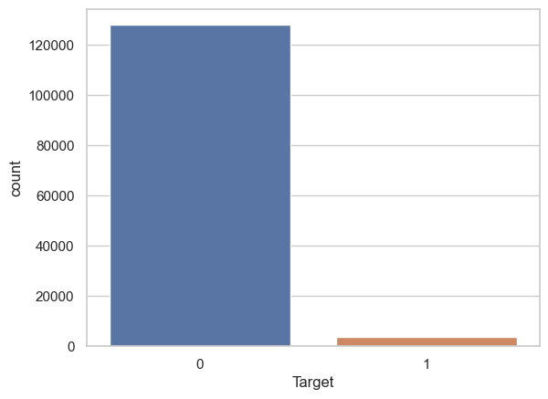

```python
import seaborn as sns
import matplotlib.pyplot as plt

# count plot on single categorical variable
sns.countplot(x =target, data = data)

# Show the plot
plt.show()
```

## 4. Explore variable of interest

### Numerical Features

```python
# Compute summary statistics for numerical features
numerical_summary = data.describe().transpose()
numerical_summary
```

|  | count | mean | std | min | 25% | 50% | 75% | max |
| --- | --- | --- | --- | --- | --- | --- | --- | --- |
| ID | 131337.0 | 77097.384180 | 44501.636704 | 1.0 | 38563.0 | 77132.0 | 115668.0 | 154139.0 |
| Target | 131337.0 | 0.026809 | 0.161525 | 0.0 | 0.0 | 0.0 | 0.0 | 1.0 |
| age_of_vehicle_years | 131337.0 | 5.493022 | 2.843299 | 1.0 | 3.0 | 5.0 | 8.0 | 10.0 |
| sched_serv_warr | 131337.0 | 5.452500 | 2.884328 | 1.0 | 3.0 | 5.0 | 8.0 | 10.0 |
| non_sched_serv_warr | 131337.0 | 5.472517 | 2.870665 | 1.0 | 3.0 | 5.0 | 8.0 | 10.0 |
| sched_serv_paid | 131337.0 | 5.452287 | 2.886528 | 1.0 | 3.0 | 5.0 | 8.0 | 10.0 |
| non_sched_serv_paid | 131337.0 | 5.497050 | 2.878699 | 1.0 | 3.0 | 5.0 | 8.0 | 10.0 |
| total_paid_services | 131337.0 | 5.481692 | 2.880408 | 1.0 | 3.0 | 5.0 | 8.0 | 10.0 |
| total_services | 131337.0 | 5.454967 | 2.875961 | 1.0 | 3.0 | 5.0 | 8.0 | 10.0 |
| mth_since_last_serv | 131337.0 | 5.469807 | 2.859756 | 1.0 | 3.0 | 5.0 | 8.0 | 10.0 |
| annualised_mileage | 131337.0 | 5.502836 | 2.854896 | 1.0 | 3.0 | 5.0 | 8.0 | 10.0 |
| num_dealers_visited | 131337.0 | 5.485438 | 2.876772 | 1.0 | 3.0 | 5.0 | 8.0 | 10.0 |
| num_serv_dealer_purchased | 131337.0 | 5.480778 | 2.867524 | 1.0 | 3.0 | 5.0 | 8.0 | 10.0 |

##### Exploring numerical features

```python
# Selecting numerical features
numerical_features = data.select_dtypes(include=['int64'])
```

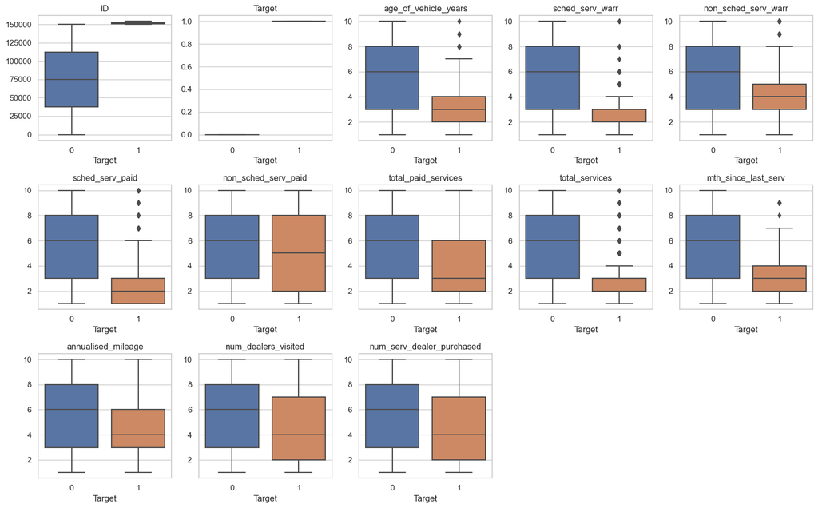

```python
# Plotting boxplots for numerical features
plt.figure(figsize=(16, 10))
for i, col in enumerate(numerical_features.columns):
    plt.subplot(3, 5, i + 1)
    sns.boxplot(data=data, x='Target', y=col)
    plt.title(col)
    plt.xlabel('Target')
    plt.ylabel('')
plt.tight_layout()
plt.show()
```

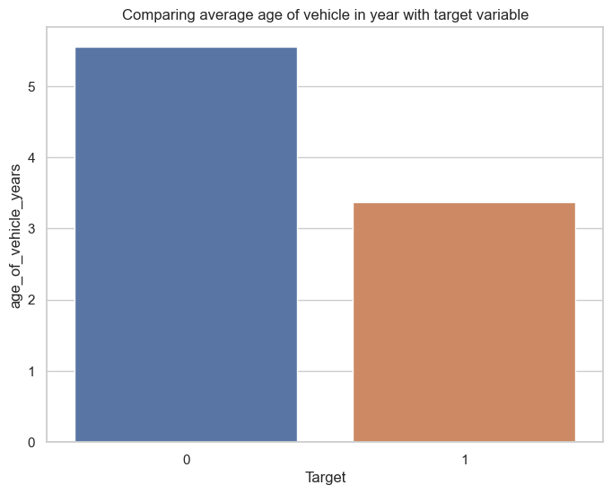

```python
plt.figure(figsize=(8,6))
sns.barplot(x="Target",y="age_of_vehicle_years",data=data,ci= False)
plt.title("Comparing average age of vehicle in year with target variable")
plt.show()
```

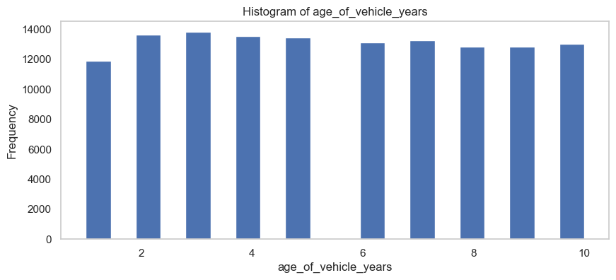

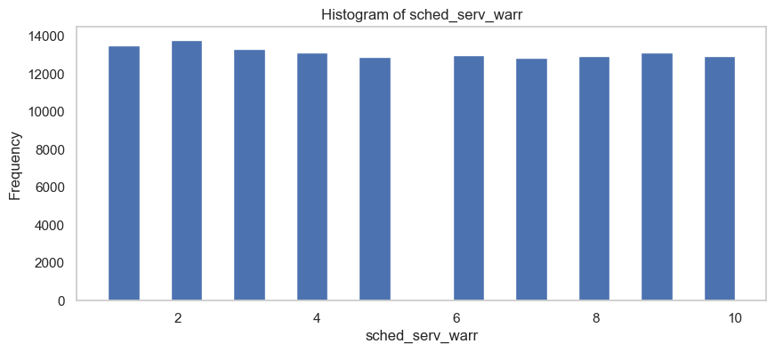

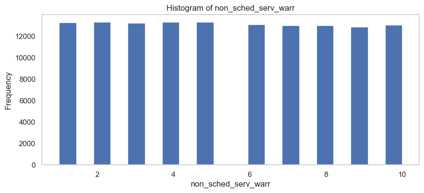

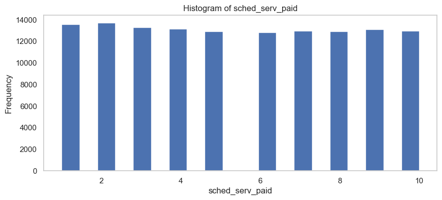

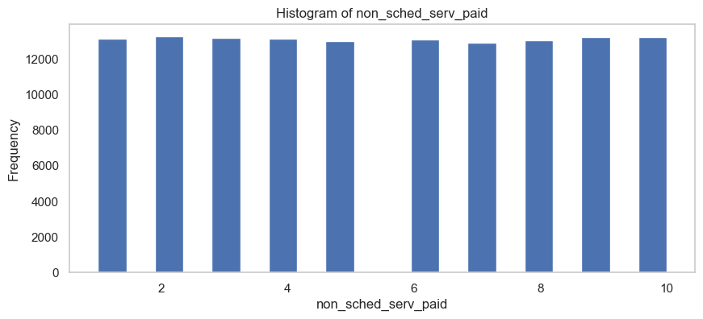

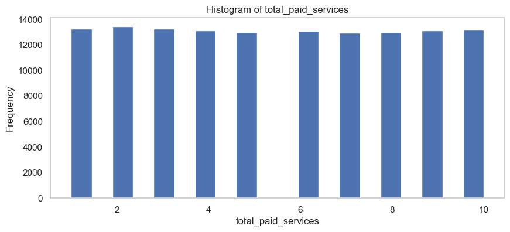

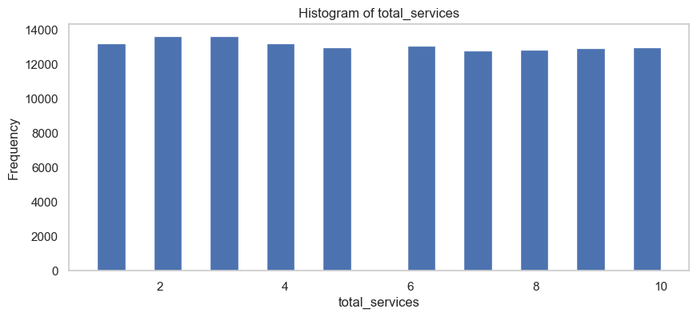

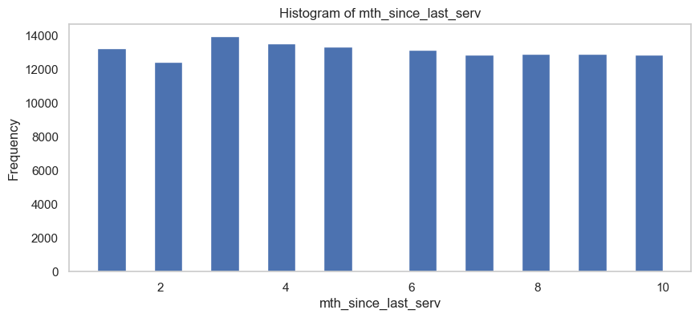

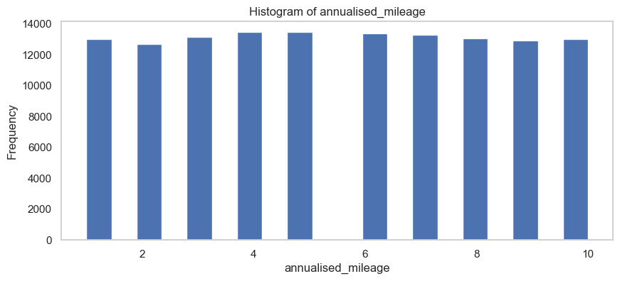

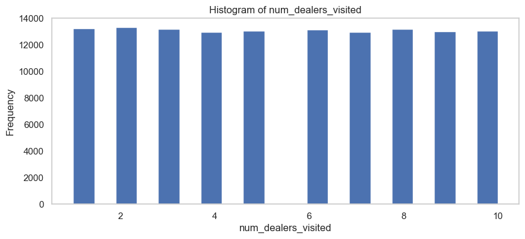

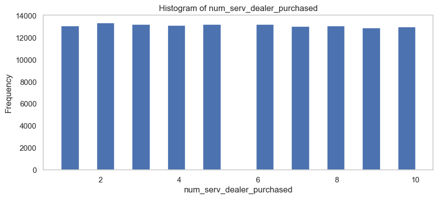

```python
import pandas as pd
import matplotlib.pyplot as plt


numerical_features = ['age_of_vehicle_years', 'sched_serv_warr', 'non_sched_serv_warr',
                      'sched_serv_paid', 'non_sched_serv_paid', 'total_paid_services',
                      'total_services', 'mth_since_last_serv', 'annualised_mileage',
                      'num_dealers_visited', 'num_serv_dealer_purchased']

# Create a histogram for each numerical feature
for feature in numerical_features:
    plt.figure(figsize=(10, 4))  # Adjust the size of the figure as needed
    data[feature].hist(bins=20)  # You can adjust the number of bins for better granularity
    plt.title(f'Histogram of {feature}')
    plt.xlabel(feature)
    plt.ylabel('Frequency')
    plt.grid(False)  # Turn off the grid for a cleaner plot
    plt.show()
```

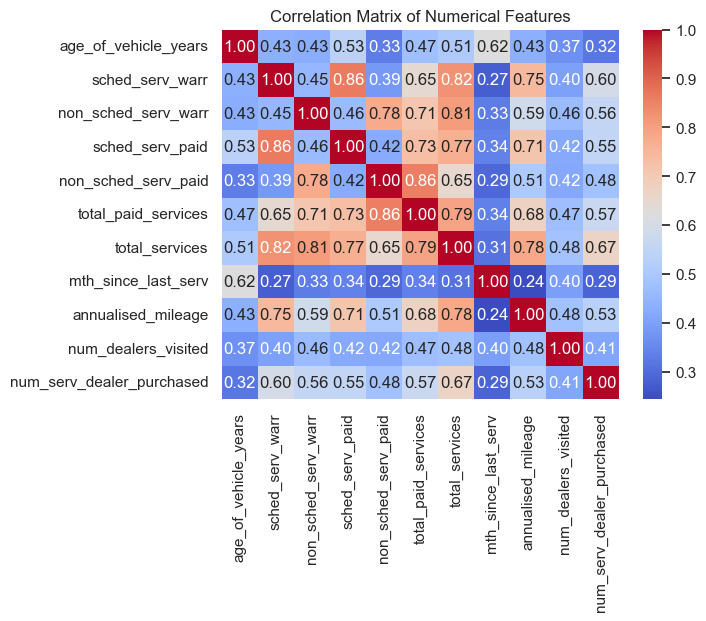

```python
numerical_features = ['age_of_vehicle_years', 'sched_serv_warr', 'non_sched_serv_warr', 'sched_serv_paid', 'non_sched_serv_paid', 'total_paid_services', 'total_services', 'mth_since_last_serv', 'annualised_mileage', 'num_dealers_visited', 'num_serv_dealer_purchased']

# Select only the numerical features from the DataFrame
numerical_data = data[numerical_features]

# Compute the correlation matrix
correlation_matrix = numerical_data.corr()

# Plot the correlation matrix using a heatmap
sns.heatmap(correlation_matrix, annot=True, cmap='coolwarm', fmt=".2f")
plt.title('Correlation Matrix of Numerical Features')
plt.show()
```

##### Correlation Matrix of Numerical Features'

### Categorial Features

```python
# categorical summary
categorical_features = data.select_dtypes(include=['object'])

# Generate summary statistics for categorical features
categorical_summary = categorical_features.describe(include=['object']).transpose()
print(categorical_summary)
```

```
              count unique           top   freq
age_band      18962      7   4. 45 to 54   4058
gender        62029      2          Male  36072
car_model    131337     19       model_2  34491
car_segment  131337      4  Small/Medium  54553
```

```python
from scipy.stats import chi2_contingency
categorical_features = ['age_band', 'gender', 'car_model', 'car_segment']

# Loop through each categorical feature
for feature in categorical_features:
    # Create a contingency table for the current feature and the target variable
    cross_tab = pd.crosstab(data[feature], data['Target'])

    # Print the cross-tabulation
    print("Cross-tabulation for", feature, "and Target:")
    print(cross_tab)

    # Perform the chi-square test
    chi2, p, dof, expected = chi2_contingency(cross_tab)

    # Print the results
    print("Chi-square statistic:", chi2)
    print("p-value:", p)
    print()
```

```
Cross-tabulation for age_band and Target:
Target          0   1
age_band
1. <25        963   4
2. 25 to 34  3515  33
3. 35 to 44  3787  46
4. 45 to 54  4001  57
5. 55 to 64  3341  56
6. 65 to 74  2119  21
7. 75+       1007  12
Chi-square statistic: 15.182521519205954
p-value: 0.01888363579024306

Cross-tabulation for gender and Target:
Target      0    1
gender
Female  25570  387
Male    35115  957
Chi-square statistic: 95.61951798583536
p-value: 1.392269835853039e-22

Cross-tabulation for car_model and Target:
Target         0    1
car_model
model_1    14913  418
model_10    3170   45
model_11     603    9
model_12     608    6
model_13     675   39
model_14      78    0
model_15     324   10
model_16     110    4
model_17     151    2
model_18      96    5
model_19       2    0
model_2    33674  817
model_3    16407  667
model_4    14837  318
model_5    24092  582
model_6     3013   58
model_7     7871  296
model_8     6225  218
model_9      967   27
Chi-square statistic: 245.67851020434293
p-value: 6.16246443089934e-42

Cross-tabulation for car_segment and Target:
Target            0     1
car_segment
LCV           23861   745
Large/SUV     50569  1551
Other            57     1
Small/Medium  53329  1224
Chi-square statistic: 68.89240448421172
p-value: 7.368893502258584e-15
```

#### The outcome suggests that all of the examined categorical features (age band, gender, car model, and car segment) are associated with repurchase likelihood, with gender and car model showing particularly strong associations.

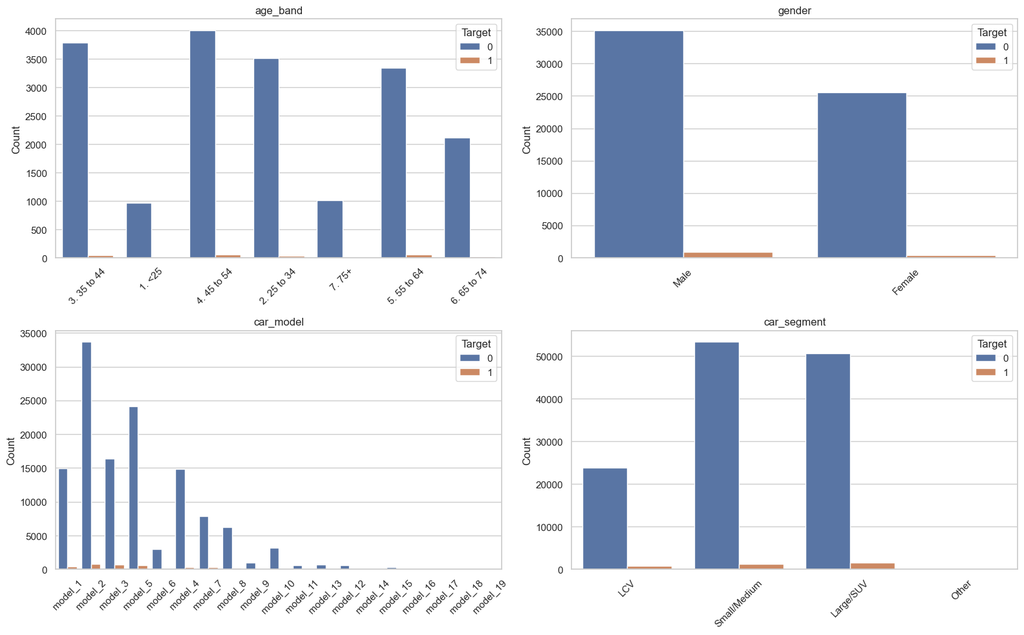

```python
# Selecting categorical features
categorical_features = data.select_dtypes(include=['object'])

# Plotting bar plots for categorical features
plt.figure(figsize=(16, 10))
for i, col in enumerate(categorical_features.columns):
    plt.subplot(2, 2, i + 1)
    sns.countplot(data=data, x=col, hue='Target')
    plt.title(col)
    plt.xlabel('')
    plt.ylabel('Count')
    plt.xticks(rotation=45)
plt.tight_layout()
plt.show()
```

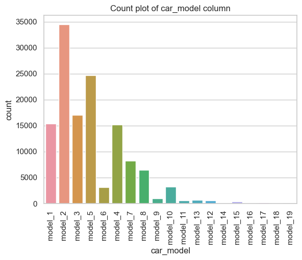

```python
# count plot
sns.countplot(x='car_model', data=data)
sns.set_palette("Set3",10)
plt.title('Count plot of car_model column')
plt.xticks(rotation=90)
plt.show()
```

## 5. Prepare dataset

```python
data.isnull()
```

|  | ID | Target | age_band | gender | car_model | car_segment | age_of_vehicle_years | sched_serv_warr | non_sched_serv_warr | sched_serv_paid | non_sched_serv_paid | total_paid_services | total_services | mth_since_last_serv | annualised_mileage | num_dealers_visited | num_serv_dealer_purchased |
| --- | --- | --- | --- | --- | --- | --- | --- | --- | --- | --- | --- | --- | --- | --- | --- | --- | --- |
| 0 | False | False | False | False | False | False | False | False | False | False | False | False | False | False | False | False | False |
| 1 | False | False | True | True | False | False | False | False | False | False | False | False | False | False | False | False | False |
| 2 | False | False | True | False | False | False | False | False | False | False | False | False | False | False | False | False | False |
| 3 | False | False | True | True | False | False | False | False | False | False | False | False | False | False | False | False | False |
| 4 | False | False | True | False | False | False | False | False | False | False | False | False | False | False | False | False | False |
| ... | ... | ... | ... | ... | ... | ... | ... | ... | ... | ... | ... | ... | ... | ... | ... | ... | ... |
| 131332 | False | False | True | True | False | False | False | False | False | False | False | False | False | False | False | False | False |
| 131333 | False | False | True | True | False | False | False | False | False | False | False | False | False | False | False | False | False |
| 131334 | False | False | True | True | False | False | False | False | False | False | False | False | False | False | False | False | False |
| 131335 | False | False | True | True | False | False | False | False | False | False | False | False | False | False | False | False | False |
| 131336 | False | False | True | True | False | False | False | False | False | False | False | False | False | False | False | False | False |

131337 rows × 17 columns

```python
data.isnull().sum()
```

```
ID                                0
Target                            0
age_band                     112375
gender                        69308
car_model                         0
car_segment                       0
age_of_vehicle_years              0
sched_serv_warr                   0
non_sched_serv_warr               0
sched_serv_paid                   0
non_sched_serv_paid               0
total_paid_services               0
total_services                    0
mth_since_last_serv               0
annualised_mileage                0
num_dealers_visited               0
num_serv_dealer_purchased         0
dtype: int64
```

```python
# Assigning a new category for missing values in 'age_band' and 'gender'
data['age_band'].fillna('Unknown', inplace=True)
data['gender'].fillna('Unknown', inplace=True)


data.isnull().sum()
```

```
ID                           0
Target                       0
age_band                     0
gender                       0
car_model                    0
car_segment                  0
age_of_vehicle_years         0
sched_serv_warr              0
non_sched_serv_warr          0
sched_serv_paid              0
non_sched_serv_paid          0
total_paid_services          0
total_services               0
mth_since_last_serv          0
annualised_mileage           0
num_dealers_visited          0
num_serv_dealer_purchased    0
dtype: int64
```

Checking if the NaN values were changed to 'Unknown'.

```python
data.head()
```

|  | ID | Target | age_band | gender | car_model | car_segment | age_of_vehicle_years | sched_serv_warr | non_sched_serv_warr | sched_serv_paid | non_sched_serv_paid | total_paid_services | total_services | mth_since_last_serv | annualised_mileage | num_dealers_visited | num_serv_dealer_purchased |
| --- | --- | --- | --- | --- | --- | --- | --- | --- | --- | --- | --- | --- | --- | --- | --- | --- | --- |
| 0 | 1 | 0 | 3. 35 to 44 | Male | model_1 | LCV | 9 | 2 | 10 | 3 | 7 | 5 | 6 | 9 | 8 | 10 | 4 |
| 1 | 2 | 0 | Unknown | Unknown | model_2 | Small/Medium | 6 | 10 | 3 | 10 | 4 | 9 | 10 | 6 | 10 | 7 | 10 |
| 2 | 3 | 0 | Unknown | Male | model_3 | Large/SUV | 9 | 10 | 9 | 10 | 9 | 10 | 10 | 7 | 10 | 6 | 10 |
| 3 | 5 | 0 | Unknown | Unknown | model_3 | Large/SUV | 5 | 8 | 5 | 8 | 4 | 5 | 6 | 4 | 10 | 9 | 7 |
| 4 | 6 | 0 | Unknown | Female | model_2 | Small/Medium | 8 | 9 | 4 | 10 | 7 | 9 | 8 | 5 | 4 | 4 | 9 |

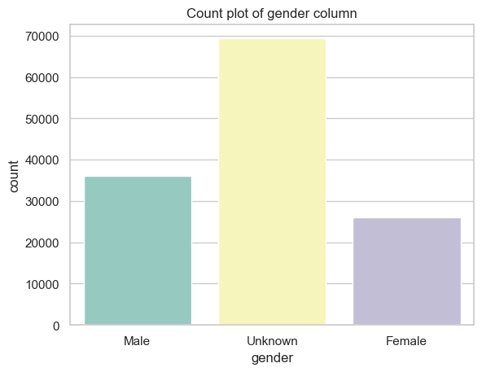

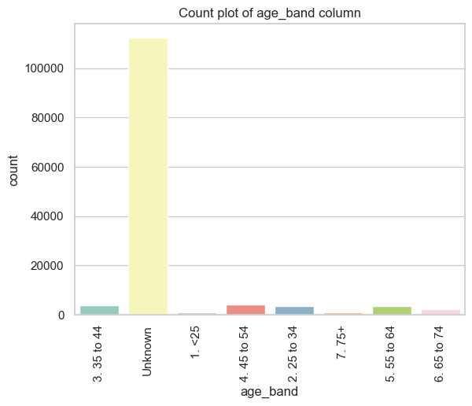

```python
# count plot
sns.countplot(x='gender', data=data)
plt.title('Count plot of gender column')
plt.show()

# count plot
sns.countplot(x='age_band', data=data)
sns.set_palette("Set3",10)
plt.title('Count plot of age_band column')
plt.xticks(rotation=90)
plt.show()
```

#### From chi_sq test, gender and car_model can be considered to be contributor for repruchase of car.

#### columns like age_band has high number of unkown counts compared to other values of counts and ID columns does not directly

#### contribute in model prediction therefore the two columns are dropped

```python
# dropping the age_band column as it is having alot of null
data.drop('age_band', axis=1, inplace=True)
data.drop('ID', axis=1, inplace=True)
```

```python
data.head()
```

|  | Target | gender | car_model | car_segment | age_of_vehicle_years | sched_serv_warr | non_sched_serv_warr | sched_serv_paid | non_sched_serv_paid | total_paid_services | total_services | mth_since_last_serv | annualised_mileage | num_dealers_visited | num_serv_dealer_purchased |
| --- | --- | --- | --- | --- | --- | --- | --- | --- | --- | --- | --- | --- | --- | --- | --- |
| 0 | 0 | Male | model_1 | LCV | 9 | 2 | 10 | 3 | 7 | 5 | 6 | 9 | 8 | 10 | 4 |
| 1 | 0 | Unknown | model_2 | Small/Medium | 6 | 10 | 3 | 10 | 4 | 9 | 10 | 6 | 10 | 7 | 10 |
| 2 | 0 | Male | model_3 | Large/SUV | 9 | 10 | 9 | 10 | 9 | 10 | 10 | 7 | 10 | 6 | 10 |
| 3 | 0 | Unknown | model_3 | Large/SUV | 5 | 8 | 5 | 8 | 4 | 5 | 6 | 4 | 10 | 9 | 7 |
| 4 | 0 | Female | model_2 | Small/Medium | 8 | 9 | 4 | 10 | 7 | 9 | 8 | 5 | 4 | 4 | 9 |

```python
data_new = data.copy()

# Initialize the LabelEncoder
le = LabelEncoder()

# Loop through each column in the DataFrame
for column in data_new.columns:
    if data_new[column].dtype == 'object':  # Checking if the column is of type object (string)
        # Apply Label Encoding to the column
        data_new[column] = le.fit_transform(data_new[column])

# Check the transformed data
data_new.head()
```

|  | Target | gender | car_model | car_segment | age_of_vehicle_years | sched_serv_warr | non_sched_serv_warr | sched_serv_paid | non_sched_serv_paid | total_paid_services | total_services | mth_since_last_serv | annualised_mileage | num_dealers_visited | num_serv_dealer_purchased |
| --- | --- | --- | --- | --- | --- | --- | --- | --- | --- | --- | --- | --- | --- | --- | --- |
| 0 | 0 | 1 | 0 | 0 | 9 | 2 | 10 | 3 | 7 | 5 | 6 | 9 | 8 | 10 | 4 |
| 1 | 0 | 2 | 11 | 3 | 6 | 10 | 3 | 10 | 4 | 9 | 10 | 6 | 10 | 7 | 10 |
| 2 | 0 | 1 | 12 | 1 | 9 | 10 | 9 | 10 | 9 | 10 | 10 | 7 | 10 | 6 | 10 |
| 3 | 0 | 2 | 12 | 1 | 5 | 8 | 5 | 8 | 4 | 5 | 6 | 4 | 10 | 9 | 7 |
| 4 | 0 | 0 | 11 | 3 | 8 | 9 | 4 | 10 | 7 | 9 | 8 | 5 | 4 | 4 | 9 |

#### all the categorical features are changed into numerical values. ex - car_model, gender

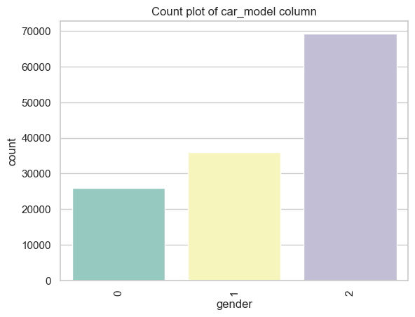

```python
# count plot
sns.countplot(x='gender', data=data_new)
sns.set_palette("Set3",10)
plt.title('Count plot of car_model column')
plt.xticks(rotation=90)
plt.show()
```

```python
from sklearn.preprocessing import OneHotEncoder
import pandas as pd

# Assuming 'data_new' is your current DataFrame
# Selecting additional features for OneHot encoding
features_to_encode = ['gender', 'car_segment', 'annualised_mileage', 'total_paid_services', 'age_of_vehicle_years', 'car_model']

# Applying OneHotEncoder to the selected features
ohe_additional = OneHotEncoder(sparse=False)
additional_features_ohe = ohe_additional.fit_transform(data_new[features_to_encode])

# Generate appropriate column names for each one-hot encoded feature
column_names = []
for feature, categories in zip(features_to_encode, ohe_additional.categories_):
    column_names.extend([f"{feature}_{category}" for category in categories])

# Convert the OneHot encoded matrix back to a DataFrame with appropriate column names
additional_features_ohe_df = pd.DataFrame(additional_features_ohe, columns=column_names)

# Concatenate the original DataFrame with the new OneHot encoded DataFrame
# Exclude the original versions of the encoded features from the DataFrame before concatenating
data_new = pd.concat([data_new.drop(features_to_encode, axis=1), additional_features_ohe_df], axis=1)

# Display the first few rows of the newly encoded DataFrame
data_new.head()
```

|  | Target | sched_serv_warr | non_sched_serv_warr | sched_serv_paid | non_sched_serv_paid | total_services | mth_since_last_serv | num_dealers_visited | num_serv_dealer_purchased | gender_0 | ... | car_model_9 | car_model_10 | car_model_11 | car_model_12 | car_model_13 | car_model_14 | car_model_15 | car_model_16 | car_model_17 | car_model_18 |
| --- | --- | --- | --- | --- | --- | --- | --- | --- | --- | --- | --- | --- | --- | --- | --- | --- | --- | --- | --- | --- | --- |
| 0 | 0 | 2 | 10 | 3 | 7 | 6 | 9 | 10 | 4 | 0.0 | ... | 0.0 | 0.0 | 0.0 | 0.0 | 0.0 | 0.0 | 0.0 | 0.0 | 0.0 | 0.0 |
| 1 | 0 | 10 | 3 | 10 | 4 | 10 | 6 | 7 | 10 | 0.0 | ... | 0.0 | 0.0 | 1.0 | 0.0 | 0.0 | 0.0 | 0.0 | 0.0 | 0.0 | 0.0 |
| 2 | 0 | 10 | 9 | 10 | 9 | 10 | 7 | 6 | 10 | 0.0 | ... | 0.0 | 0.0 | 0.0 | 1.0 | 0.0 | 0.0 | 0.0 | 0.0 | 0.0 | 0.0 |
| 3 | 0 | 8 | 5 | 8 | 4 | 6 | 4 | 9 | 7 | 0.0 | ... | 0.0 | 0.0 | 0.0 | 1.0 | 0.0 | 0.0 | 0.0 | 0.0 | 0.0 | 0.0 |
| 4 | 0 | 9 | 4 | 10 | 7 | 8 | 5 | 4 | 9 | 1.0 | ... | 0.0 | 0.0 | 1.0 | 0.0 | 0.0 | 0.0 | 0.0 | 0.0 | 0.0 | 0.0 |

5 rows × 65 columns

```python
data_new.info()
```

```
<class 'pandas.core.frame.DataFrame'>
RangeIndex: 131337 entries, 0 to 131336
Data columns (total 65 columns):
 #   Column                     Non-Null Count   Dtype
---  ------                     --------------   -----
 0   Target                     131337 non-null  int64
 1   sched_serv_warr            131337 non-null  int64
 2   non_sched_serv_warr        131337 non-null  int64
 3   sched_serv_paid            131337 non-null  int64
 4   non_sched_serv_paid        131337 non-null  int64
 5   total_services             131337 non-null  int64
 6   mth_since_last_serv        131337 non-null  int64
 7   num_dealers_visited        131337 non-null  int64
 8   num_serv_dealer_purchased  131337 non-null  int64
 9   gender_0                   131337 non-null  float64
```

[output cut: 57 more lines]

```python
print(data_new['gender_0'].unique())
print(data_new['car_segment_0'].unique())
```

```
[0. 1.]
[1. 0.]
```

```python
print(data_new.columns)
```

```
Index(['Target', 'sched_serv_warr', 'non_sched_serv_warr', 'sched_serv_paid',
       'non_sched_serv_paid', 'total_services', 'mth_since_last_serv',
       'num_dealers_visited', 'num_serv_dealer_purchased', 'gender_0',
       'gender_1', 'gender_2', 'car_segment_0', 'car_segment_1',
       'car_segment_2', 'car_segment_3', 'annualised_mileage_1',
       'annualised_mileage_2', 'annualised_mileage_3', 'annualised_mileage_4',
       'annualised_mileage_5', 'annualised_mileage_6', 'annualised_mileage_7',
       'annualised_mileage_8', 'annualised_mileage_9', 'annualised_mileage_10',
       'total_paid_services_1', 'total_paid_services_2',
       'total_paid_services_3', 'total_paid_services_4',
       'total_paid_services_5', 'total_paid_services_6',
       'total_paid_services_7', 'total_paid_services_8',
       'total_paid_services_9', 'total_paid_services_10',
       'age_of_vehicle_years_1', 'age_of_vehicle_years_2',
       'age_of_vehicle_years_3', 'age_of_vehicle_years_4',
       'age_of_vehicle_years_5', 'age_of_vehicle_years_6',
       'age_of_vehicle_years_7', 'age_of_vehicle_years_8',
       'age_of_vehicle_years_9', 'age_of_vehicle_years_10', 'car_model_0',
       'car_model_1', 'car_model_2', 'car_model_3', 'car_model_4',
       'car_model_5', 'car_model_6', 'car_model_7', 'car_model_8',
       'car_model_9', 'car_model_10', 'car_model_11', 'car_model_12',
       'car_model_13', 'car_model_14', 'car_model_15', 'car_model_16',
       'car_model_17', 'car_model_18'],
      dtype='object')
```

#### One hot-encoding has suscessfully implemeneted

### 6. Split the data into train and test sets

```python
X = data_new.drop('Target', axis=1)
y = data_new['Target']
X_train, X_test, y_train, y_test = train_test_split(X, y, test_size=0.2, random_state=42)
```

```python
X_train
```

|  | sched_serv_warr | non_sched_serv_warr | sched_serv_paid | non_sched_serv_paid | total_services | mth_since_last_serv | num_dealers_visited | num_serv_dealer_purchased | gender_0 | gender_1 | ... | car_model_9 | car_model_10 | car_model_11 | car_model_12 | car_model_13 | car_model_14 | car_model_15 | car_model_16 | car_model_17 | car_model_18 |
| --- | --- | --- | --- | --- | --- | --- | --- | --- | --- | --- | --- | --- | --- | --- | --- | --- | --- | --- | --- | --- | --- |
| 76012 | 8 | 3 | 6 | 5 | 6 | 7 | 5 | 7 | 0.0 | 0.0 | ... | 0.0 | 0.0 | 0.0 | 1.0 | 0.0 | 0.0 | 0.0 | 0.0 | 0.0 | 0.0 |
| 48072 | 9 | 5 | 6 | 3 | 7 | 7 | 4 | 8 | 0.0 | 0.0 | ... | 0.0 | 0.0 | 0.0 | 1.0 | 0.0 | 0.0 | 0.0 | 0.0 | 0.0 | 0.0 |
| 17713 | 6 | 10 | 3 | 10 | 10 | 6 | 8 | 7 | 0.0 | 0.0 | ... | 0.0 | 0.0 | 0.0 | 0.0 | 0.0 | 0.0 | 0.0 | 0.0 | 0.0 | 0.0 |
| 116540 | 7 | 3 | 5 | 2 | 4 | 7 | 1 | 1 | 0.0 | 0.0 | ... | 0.0 | 0.0 | 0.0 | 0.0 | 0.0 | 0.0 | 0.0 | 0.0 | 0.0 | 0.0 |
| 71027 | 2 | 4 | 2 | 4 | 3 | 3 | 3 | 4 | 0.0 | 0.0 | ... | 0.0 | 0.0 | 1.0 | 0.0 | 0.0 | 0.0 | 0.0 | 0.0 | 0.0 | 0.0 |
| ... | ... | ... | ... | ... | ... | ... | ... | ... | ... | ... | ... | ... | ... | ... | ... | ... | ... | ... | ... | ... | ... |
| 54886 | 6 | 3 | 6 | 1 | 4 | 4 | 4 | 3 | 0.0 | 0.0 | ... | 0.0 | 0.0 | 0.0 | 0.0 | 0.0 | 0.0 | 0.0 | 0.0 | 1.0 | 0.0 |
| 110268 | 10 | 8 | 10 | 10 | 9 | 3 | 3 | 10 | 0.0 | 1.0 | ... | 0.0 | 0.0 | 1.0 | 0.0 | 0.0 | 0.0 | 0.0 | 0.0 | 0.0 | 0.0 |
| 119879 | 8 | 4 | 10 | 4 | 6 | 10 | 4 | 8 | 0.0 | 0.0 | ... | 0.0 | 0.0 | 1.0 | 0.0 | 0.0 | 0.0 | 0.0 | 0.0 | 0.0 | 0.0 |
| 103694 | 8 | 8 | 10 | 8 | 7 | 3 | 6 | 9 | 0.0 | 0.0 | ... | 0.0 | 0.0 | 0.0 | 0.0 | 0.0 | 1.0 | 0.0 | 0.0 | 0.0 | 0.0 |
| 121958 | 8 | 4 | 5 | 3 | 6 | 6 | 2 | 3 | 1.0 | 0.0 | ... | 0.0 | 0.0 | 0.0 | 0.0 | 1.0 | 0.0 | 0.0 | 0.0 | 0.0 | 0.0 |

105069 rows × 64 columns

```python
y_train
```

```
76012     0
48072     0
17713     0
116540    0
71027     0
         ..
54886     0
110268    0
119879    0
103694    0
121958    0
Name: Target, Length: 105069, dtype: int64
```

### 7. Train the model

```python
from sklearn.ensemble import RandomForestClassifier
clf = RandomForestClassifier(random_state=42)
clf.fit(X_train, y_train)
```

```
RandomForestClassifier(random_state=42)
```

```python
y_pred = clf.predict(X_test)
print('Accuracy:', accuracy_score(y_test, y_pred))
print('Precision:', precision_score(y_test, y_pred))
print('Recall:', recall_score(y_test, y_pred))
print('F1-score:', f1_score(y_test, y_pred))
print('ROC AUC score:', roc_auc_score(y_test, clf.predict_proba(X_test)[:,1]))
```

```
Accuracy: 0.992462311557789
Precision: 0.9583333333333334
Recall: 0.7318181818181818
F1-score: 0.8298969072164948
ROC AUC score: 0.9934168595514659
```

#### Hyperparameter grid to search

```python
from sklearn.ensemble import RandomForestClassifier
from sklearn.model_selection import GridSearchCV
from sklearn.metrics import accuracy_score, precision_score, recall_score, f1_score

# Split the data into training and testing sets
X_train, X_test, y_train, y_test = train_test_split(X, y, test_size=0.3, random_state=42)

# Define the hyperparameter grid to search
param_grid = {
    'n_estimators': [50, 100, 150],
    'max_depth': [None, 5, 10],
    'min_samples_split': [2, 5],
    'min_samples_leaf': [1, 2],
    'max_features': ['auto', 'sqrt', 'log2']
}

# Create a Random Forest classifier object
rfc = RandomForestClassifier(random_state=42)

# Create a GridSearchCV object to search for the best hyperparameters
grid_search = GridSearchCV(rfc, param_grid, cv=5, n_jobs=-1)

# Fit the GridSearchCV object to the training data
grid_search.fit(X_train, y_train)

# Print the best hyperparameters
print("Best hyperparameters:", grid_search.best_params_)

# Predict the labels of the test set using the best estimator
y_pred = grid_search.best_estimator_.predict(X_test)

# Evaluate the performance of the model using various metrics
print("Accuracy:", accuracy_score(y_test, y_pred))
print("Precision:", precision_score(y_test, y_pred))
print("Recall:", recall_score(y_test, y_pred))
print("F1-Score:", f1_score(y_test, y_pred))
```

```
Best hyperparameters: {'max_depth': None, 'max_features': 'auto', 'min_samples_leaf': 1, 'min_samples_split': 2, 'n_estimators': 150}
Accuracy: 0.9917263083092229
Precision: 0.9583333333333334
Recall: 0.7145631067961165
F1-Score: 0.8186874304783092
```

### 8. Assess Model Performance

```python
#confusion matrix
from sklearn.metrics import confusion_matrix
conf_matrix = confusion_matrix(y_test, y_pred)
print(conf_matrix)
```

```
[[38340    32]
 [  294   736]]
```

```python
# Classification Report:
from sklearn.metrics import classification_report
class_report = classification_report(y_test, y_pred, target_names=['Not Repurchase', 'Repurchase'])
print(class_report)
```

```
                precision    recall  f1-score   support

Not Repurchase       0.99      1.00      1.00     38372
    Repurchase       0.96      0.71      0.82      1030

      accuracy                           0.99     39402
     macro avg       0.98      0.86      0.91     39402
  weighted avg       0.99      0.99      0.99     39402
```

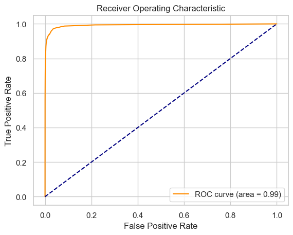

```python
#ROC Curve and AUC Score:
from sklearn.metrics import roc_curve, auc
import matplotlib.pyplot as plt
fpr, tpr, thresholds = roc_curve(y_test, grid_search.best_estimator_.predict_proba(X_test)[:, 1])
roc_auc = auc(fpr, tpr)
plt.figure()
plt.plot(fpr, tpr, color='darkorange', label=f'ROC curve (area = {roc_auc:.2f})')
plt.plot([0, 1], [0, 1], color='navy', linestyle='--')
plt.xlabel('False Positive Rate')
plt.ylabel('True Positive Rate')
plt.title('Receiver Operating Characteristic')
plt.legend(loc="lower right")
plt.show()
```

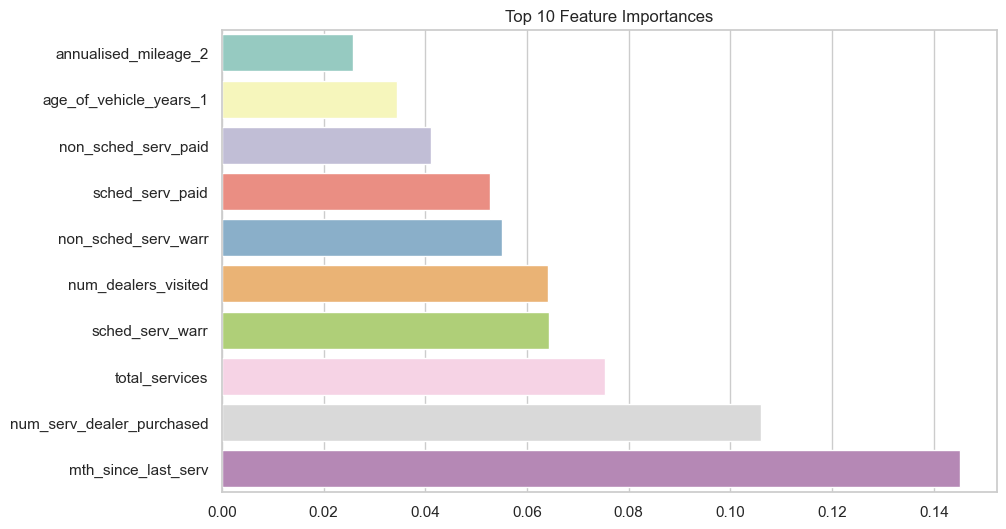

```python
#Feature Importance:
import seaborn as sns
feature_importances = pd.Series(grid_search.best_estimator_.feature_importances_, index=X.columns)
top_features = feature_importances.nlargest(10).sort_values()
plt.figure(figsize=(10, 6))
sns.barplot(x=top_features.values, y=top_features.index, orient='h')
plt.title('Top 10 Feature Importances')
plt.show()
```

```python
feature_importances = pd.Series(grid_search.best_estimator_.feature_importances_, index=X.columns)

# Get the top 10 features sorted by importance
top_features = feature_importances.nlargest(10)

# Print the names and importance scores of the top 10 features
print("Top 10 Feature Importances:")
print(top_features)
```

```
Top 10 Feature Importances:
mth_since_last_serv          0.145135
num_serv_dealer_purchased    0.105998
total_services               0.075330
sched_serv_warr              0.064262
num_dealers_visited          0.064199
non_sched_serv_warr          0.055078
sched_serv_paid              0.052712
non_sched_serv_paid          0.041147
age_of_vehicle_years_1       0.034393
annualised_mileage_2         0.025769
dtype: float64
```

```python
#cross validation
from sklearn.model_selection import cross_val_score
cv_scores = cross_val_score(grid_search.best_estimator_, X, y, cv=5)
print("Cross-validation Mean:", cv_scores.mean(), "Standard Deviation:", cv_scores.std())
```

```
Cross-validation Mean: 0.9881678327065313 Standard Deviation: 0.0009469503660424592
```

Result Cross-validation Mean Accuracy: 98.82% Standard Deviation: 0.0947%

These results indicate that the model exhibits consistent performance across different folds, with a very high average accuracy and a low standard deviation. The tight standard deviation underscores the model's stability, suggesting that its performance is robust across varying data samples.